# Histogram MSR1 v WNT2

Alvaro Regano

28/09/2021

# 1 About the analysis

The data was taken from the Liver 20-01-21 sample processed by Carlos Torroja. In brief, we want to find out if there is a unbalance in the arterio-venous differentiation of LOF cells in the 3 conditions (Dll4LOF, RbpjLOF and Notch1LOF). For that we have selected 2 markers, MSR1 and WNT2, the former a validated arterial marker and the latter a venous one.

In the analysis we will first subset the samples in the 4 different Conditions (Control, Dll4KO, RbpjKO and Notch1KO) and then withing each conditions the samples will be further subset in terms of their expression rates following this criteria:

no expression = MSR1 and WNT2<=0

MSR1lo-noWNT2 = 0<MSR1<=2 and WNT2<=0

MSR1hi-noWNT2 = MSR1>2 and WNT2<=0

noMSR1-WNT2lo = MSR1<=0 and 0<WNT2<=2

MSR1lo-WNT2lo = 0<MSR1<=2 and 0<WNT2<=2

MSR1hi-WNT2lo = MSR1>2 and 0<WNT2<=2

MSR1lo-WNT2hi = 0<MSR1<=2 and WNT2>2

MSR1hi-WNT2hi = MSR1>2 and WNT2>2

# 2 Objective

The goal is to find that if the LOF of various genes involved in the Notch pathway (Dll4, Rbpj and Notch1) cause any changes in the arterio-venous differentiation pattern in liver cells of adult mice

# 3 Analysis

```r
library("Seurat")
library("ggplot2")
library("RColorBrewer")
```

```r
  Carlos <- readRDS("SC.Analysis.SecondPass.RNA.Singlets.Endothelial.ManualClustering.seuratSC.Final.V4.rds")
  Control <- subset(x = Carlos, subset = Condition == "Control")
  Dll4KO <- subset(x = Carlos, subset = Condition == "Dll4KO")
  RbpjKO <- subset(x = Carlos, subset = Condition == "RBPJKO")
  Notch1KO <- subset(x = Carlos, subset = Condition == "NOTCH1KO")

  my_palette <- c(black="#000000", brewer.pal(9, "RdBu"))
```

```r
  lo_lo <- subset(Control, subset = MSR1 <= 0 & WNT2 <= 0)
  med_lo <- subset(Control, subset = MSR1 > 0 & MSR1 <= 2 & WNT2 <= 0)
  hi_lo <- subset(Control, subset = MSR1 > 2 & WNT2 <= 0)

  lo_med <- subset(Control, subset = MSR1 <= 0 & WNT2 > 0 & WNT2 <= 2)
  med_med <- subset(Control, subset = MSR1 > 0 & MSR1 <= 2 & WNT2 > 0 & WNT2 <= 2)
  hi_med <- subset(Control, subset = MSR1 > 2 & WNT2 > 0 & WNT2 <= 2)

  lo_hi <- subset(Control, subset = MSR1 <= 0 & WNT2 > 0)
  med_hi <- subset(Control, subset = MSR1 > 0 & MSR1 <= 2 & WNT2 > 2)
  hi_hi <- subset(Control, subset = MSR1 > 2 & WNT2 > 2)

  h0 <- ncol(lo_lo)
  h1 <- ncol(hi_lo)
  h2 <- ncol(med_lo)
  h3 <- ncol(hi_med)
  h4 <- ncol(med_med)/2
  h5 <- ncol(hi_hi)
  h6 <- ncol(med_med)/2
  h7 <- ncol(med_hi)
  h8 <- ncol(lo_med)
  h9 <- ncol(lo_hi)


  ncell_list_Control <- matrix(c(h0, h1, h2, h3, h4, h5, h6, h7, h8, h9), ncol = 1)
```

```r
  lo_lo <- subset(Dll4KO, subset = MSR1 <= 0 & WNT2 <= 0)
  med_lo <- subset(Dll4KO, subset = MSR1 > 0 & MSR1 <= 2 & WNT2 <= 0)
  #No cells found
  #hi_lo <- subset(Dll4KO, subset = MSR1 > 2 & WNT2 <= 0)
  hi_lo <- 0

  lo_med <- subset(Dll4KO, subset = MSR1 <= 0 & WNT2 > 0 & WNT2 <= 2)
  med_med <- subset(Dll4KO, subset = MSR1 > 0 & MSR1 <= 2 & WNT2 > 0 & WNT2 <= 2)
  #No cells found
  #hi_med <- subset(Dll4KO, subset = MSR1 > 2 & WNT2 > 0 & WNT2 <= 2)
  hi_med <- 0

  lo_hi <- subset(Dll4KO, subset = MSR1 <= 0 & WNT2 > 0)
  med_hi <- subset(Dll4KO, subset = MSR1 > 0 & MSR1 <= 2 & WNT2 > 2)
  #No cells found
  #hi_hi <- subset(Dll4KO, subset = MSR1 > 2 & WNT2 > 2)
  hi_hi <- 0

  h0 <- ncol(lo_lo)
  h1 <- ncol(hi_lo)
  h2 <- ncol(med_lo)
  h3 <- ncol(hi_med)
  h4 <- ncol(med_med)/2
  h5 <- ncol(hi_hi)
  h6 <- ncol(med_med)/2
  h7 <- ncol(med_hi)
  h8 <- ncol(lo_med)
  h9 <- ncol(lo_hi)


  ncell_list_Dll4KO <- matrix(c(h0, 0, h2, 0, h4, 0, h6, h7, h8, h9), ncol = 1)
```

```r
  lo_lo <- subset(RbpjKO, subset = MSR1 <= 0 & WNT2 <= 0)
  med_lo <- subset(RbpjKO, subset = MSR1 > 0 & MSR1 <= 2 & WNT2 <= 0)
  hi_lo <- subset(RbpjKO, subset = MSR1 > 2 & WNT2 <= 0)

  lo_med <- subset(RbpjKO, subset = MSR1 <= 0 & WNT2 > 0 & WNT2 <= 2)
  med_med <- subset(RbpjKO, subset = MSR1 > 0 & MSR1 <= 2 & WNT2 > 0 & WNT2 <= 2)
  hi_med <- subset(RbpjKO, subset = MSR1 > 2 & WNT2 > 0 & WNT2 <= 2)

  lo_hi <- subset(RbpjKO, subset = MSR1 <= 0 & WNT2 > 0)
  med_hi <- subset(RbpjKO, subset = MSR1 > 0 & MSR1 <= 2 & WNT2 > 2)
  hi_hi <- subset(RbpjKO, subset = MSR1 > 2 & WNT2 > 2)

  h0 <- ncol(lo_lo)
  h1 <- ncol(hi_lo)
  h2 <- ncol(med_lo)
  h3 <- ncol(hi_med)
  h4 <- ncol(med_med)/2
  h5 <- ncol(hi_hi)
  h6 <- ncol(med_med)/2
  h7 <- ncol(med_hi)
  h8 <- ncol(lo_med)
  h9 <- ncol(lo_hi)


  ncell_list_RbpjKO <- matrix(c(h0, h1, h2, h3, h4, h5, h6, h7, h8, h9), ncol = 1)
```

```r
  lo_lo <- subset(Notch1KO, subset = MSR1 <= 0 & WNT2 <= 0)
  med_lo <- subset(Notch1KO, subset = MSR1 > 0 & MSR1 <= 2 & WNT2 <= 0)
  hi_lo <- subset(Notch1KO, subset = MSR1 > 2 & WNT2 <= 0)

  lo_med <- subset(Notch1KO, subset = MSR1 <= 0 & WNT2 > 0 & WNT2 <= 2)
  med_med <- subset(Notch1KO, subset = MSR1 > 0 & MSR1 <= 2 & WNT2 > 0 & WNT2 <= 2)
  hi_med <- subset(Notch1KO, subset = MSR1 > 2 & WNT2 > 0 & WNT2 <= 2)

  lo_hi <- subset(Notch1KO, subset = MSR1 <= 0 & WNT2 > 0)
  med_hi <- subset(Notch1KO, subset = MSR1 > 0 & MSR1 <= 2 & WNT2 > 2)
  hi_hi <- subset(Notch1KO, subset = MSR1 > 2 & WNT2 > 2)

  h0 <- ncol(lo_lo)
  h1 <- ncol(hi_lo)
  h2 <- ncol(med_lo)
  h3 <- ncol(hi_med)
  h4 <- ncol(med_med)/2
  h5 <- ncol(hi_hi)
  h6 <- ncol(med_med)/2
  h7 <- ncol(med_hi)
  h8 <- ncol(lo_med)
  h9 <- ncol(lo_hi)


  ncell_list_Notch1KO <- matrix(c(h0, h1, h2, h3, h4, h5, h6, h7, h8, h9), ncol = 1)
```

```r
  ncell_list_Conditions <- matrix(c("Control" = ncell_list_Control, "Dll4KO" = ncell_list_Dll4KO, "RbpjKO" = ncell_list_RbpjKO, "Notch1KO" = ncell_list_Notch1KO), ncol = 4,
                                  dimnames = list(c("no expr", "MSR1hi-noWNT2", "MSR1lo-noWNT2", "MSR1hi-WNT2lo", "MSR1lo-WNT2lo", "MSR1hi-WNT2hi", "MSR1lo-WNT2lo", "MSR1lo-WNT2hi", "noMSR1-WNT2lo", "noMSR1-WNT2hi"),
                                               c("Control", "Dll4KO", "RbpjKO", "Notch1KO")))

ncell_list_Conditions
```

```
##               Control Dll4KO RbpjKO Notch1KO
## no expr           155    429    201      163
## MSR1hi-noWNT2     203      0     44       12
## MSR1lo-noWNT2     141    103    214       66
## MSR1hi-WNT2lo      70      0     59       17
## MSR1lo-WNT2lo      35     56    154      101
## MSR1hi-WNT2hi       3      0     10        7
## MSR1lo-WNT2lo      35     56    154      101
## MSR1lo-WNT2hi       6      4     32       51
## noMSR1-WNT2lo     165    238    160      286
## noMSR1-WNT2hi     256    275    200      435
```

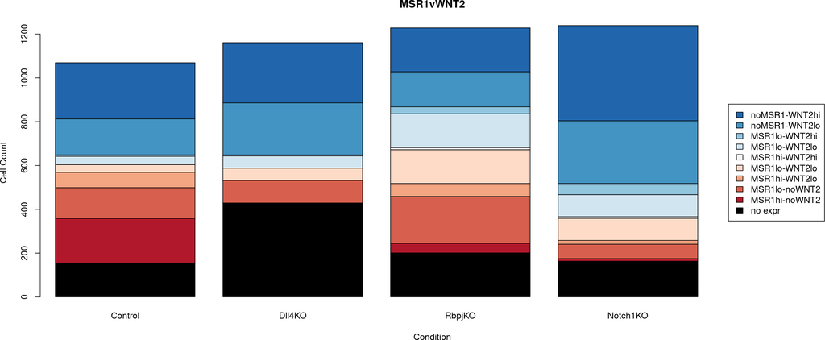

```r
  p1 <- barplot(ncell_list_Conditions, xlim = c(0.3, 5.5), col = my_palette, axisnames = T, ylab = "Cell Count", xlab = "Condition", legend.text = c("no expr", "MSR1hi-noWNT2", "MSR1lo-noWNT2", "MSR1hi-WNT2lo", "MSR1lo-WNT2lo", "MSR1hi-WNT2hi", "MSR1lo-WNT2lo", "MSR1lo-WNT2hi", "noMSR1-WNT2lo", "noMSR1-WNT2hi"), args.legend = list(x = "right", inset = c(0, 0)), main = "MSR1vWNT2")
```

```r
cells_per_condition <- colSums(ncell_list_Conditions)

cells_per_condition
```

```
##  Control   Dll4KO   RbpjKO Notch1KO
##     1069     1161     1228     1239
```

```r
ncell_list_Conditions_norm <- matrix(c(100*ncell_list_Conditions[1:10]/cells_per_condition[1], 100*ncell_list_Conditions[11:20]/cells_per_condition[2], 100*ncell_list_Conditions[21:30]/cells_per_condition[3], 100*ncell_list_Conditions[31:40]/cells_per_condition[4]), ncol = 4,
                                     dimnames = list(c("no expr", "MSR1hi-noWNT2", "MSR1lo-noWNT2", "MSR1hi-WNT2lo", "MSR1lo-WNT2lo", "MSR1hi-WNT2hi", "MSR1lo-WNT2lo", "MSR1lo-WNT2hi", "noMSR1-WNT2lo", "noMSR1-WNT2hi"),
                                                     c("Control=1069", "Dll4KO=1161", "RbpjKO=1228", "Notch1KO=1239")))

ncell_list_Conditions_norm
```

```
##               Control=1069 Dll4KO=1161 RbpjKO=1228 Notch1KO=1239
## no expr         14.4995323  36.9509044  16.3680782    13.1557708
## MSR1hi-noWNT2   18.9897100   0.0000000   3.5830619     0.9685230
## MSR1lo-noWNT2   13.1898971   8.8716624  17.4267101     5.3268765
## MSR1hi-WNT2lo    6.5481759   0.0000000   4.8045603     1.3720743
## MSR1lo-WNT2lo    3.2740879   4.8234281  12.5407166     8.1517353
## MSR1hi-WNT2hi    0.2806361   0.0000000   0.8143322     0.5649718
## MSR1lo-WNT2lo    3.2740879   4.8234281  12.5407166     8.1517353
## MSR1lo-WNT2hi    0.5612722   0.3445306   2.6058632     4.1162228
## noMSR1-WNT2lo   15.4349860  20.4995693  13.0293160    23.0831316
## noMSR1-WNT2hi   23.9476146  23.6864772  16.2866450    35.1089588
```

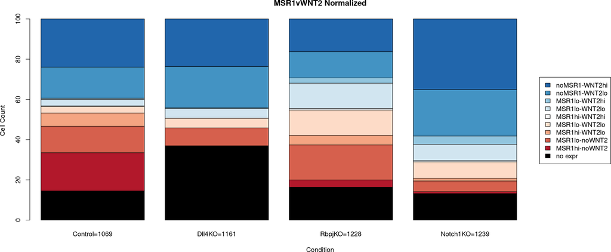

```r
p2 <- barplot(ncell_list_Conditions_norm, xlim = c(0.3, 5.5), col = my_palette, axisnames = T, ylab = "Cell Count", xlab = "Condition",
              legend.text = c("no expr", "MSR1hi-noWNT2", "MSR1lo-noWNT2", "MSR1hi-WNT2lo", "MSR1lo-WNT2lo", "MSR1hi-WNT2hi", "MSR1lo-WNT2lo", "MSR1lo-WNT2hi", "noMSR1-WNT2lo", "noMSR1-WNT2hi"),
              args.legend = list(x = "right", inset = c(0, 0)), main = "MSR1vWNT2 Normalized")
```

# 4 Conclusion

Control cells show a clearly proportional arterio-venous differentiation. However, the other conditions lose that pattern, specially Dll4KO and Notch1KO.